# An Introduction to Statistical Learning (2013)

Chapter Code

by Brian Hassett

# Chapter 3 Linear Regression

This notebook is a rough outline of **Chapter 3** of **An Introduction to Statistical Learning** (James et al. (2013)[^1]).

The authors do not provide code for the analysis or figures used throughout each chapter. They do however provide access to some of the data. This notebook uses the data to recreate *some* of the analysis and figures from the chapter.

## Setup

```r
library(ISLR)
library(tidyverse)
library(patchwork)
theme_set(theme_bw())

# Given a filename, return the filepath. Default folder is the `data` folder in the current working directory.
get_path <- function(filename) {
  str_c(getwd(), "data", filename, sep = "/")
}

# Return a table (matrix) of the coefficients of a linear model:
get_regression_coefs <- function(model, rounding) {
  table <- summary(model)$coef
  return(round(table, rounding))
}
```

## 3.1 Simple Linear Regression

`Advertising` data set:

```r
Ad <- read.csv(get_path("Advertising.csv")) %>% select(-X)
Ad
```

| TV | radio | newspaper | sales |
| --- | --- | --- | --- |
| 230.1 | 37.8 | 69.2 | 22.1 |
| 44.5 | 39.3 | 45.1 | 10.4 |
| 17.2 | 45.9 | 69.3 | 9.3 |
| 151.5 | 41.3 | 58.5 | 18.5 |
| 180.8 | 10.8 | 58.4 | 12.9 |
| 8.7 | 48.9 | 75.0 | 7.2 |
| 57.5 | 32.8 | 23.5 | 11.8 |
| 120.2 | 19.6 | 11.6 | 13.2 |
| 8.6 | 2.1 | 1.0 | 4.8 |
| 199.8 | 2.6 | 21.2 | 10.6 |

[output cut: 190 more lines]

### FIGURE 2.1

This figure is displayed here again for reference:

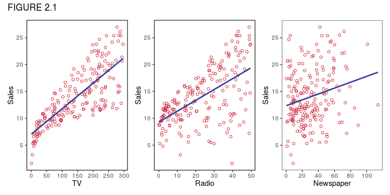

```r
colors_2.1 <- c("darkred" = "#cd2136",
             "darkblue" = "#37409e")

p1 <- ggplot(Ad, aes(TV, sales)) +
  geom_point(color = colors_2.1["darkred"], shape = 21) +
  geom_smooth(method = "lm", se = FALSE,
              color = colors_2.1["darkblue"]) +
  labs(x = "TV", y = "Sales") +
  scale_x_continuous(breaks = seq(0, 300, by = 50)) +
  scale_y_continuous(breaks = seq(5, 25, by = 5)) +
  theme(panel.grid = element_blank())

p2 <- ggplot(Ad, aes(radio, sales)) +
  geom_point(color = colors_2.1["darkred"], shape = 21) +
  geom_smooth(method = "lm", se = FALSE,
              color = colors_2.1["darkblue"]) +
  labs(x = "Radio", y = "Sales") +
  scale_x_continuous(breaks = seq(0, 50, by = 10)) +
  scale_y_continuous(breaks = seq(5, 25, by = 5)) +
  theme(panel.grid = element_blank())

p3 <- ggplot(Ad, aes(newspaper, sales)) +
  geom_point(color = colors_2.1["darkred"], shape = 21) +
  geom_smooth(method = "lm", se = FALSE,
              color = colors_2.1["darkblue"]) +
  labs(x = "Newspaper", y = "Sales") +
  scale_x_continuous(breaks = seq(0, 100, by = 20)) +
  scale_y_continuous(breaks = seq(5, 25, by = 5)) +
  theme(panel.grid = element_blank())

p1 + p2 + p3 + plot_annotation(title = "FIGURE 2.1")
```

### FIGURE 3.1

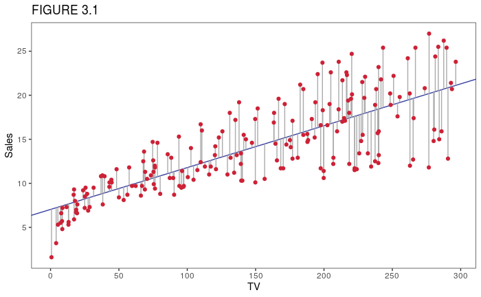

```r
# Linear model:
mod <- lm(sales ~ TV, data = Ad)

# Get a data frame of the model input data, fitted values and residuals
mod_data <- data.frame(mod$model, # the moderndive::get_regression_points() function is nice, but better to use base R in case something changes
           sales_hat = mod$fitted.values)

# Plot:
colors_3.1 <- c("darkred" = "#cd2136",
             "darkblue" = "#37409e",
             "grey" = "#ACABAB")

ggplot(Ad) +
  geom_abline(aes(intercept = mod$coefficients[1], slope = mod$coefficients[2]),
              color = colors_3.1["darkblue"]) + # geom_abline extends in either direction, geom_smooth does not
  geom_segment(data = mod_data,
               aes(x = TV, xend = TV,
                   y = sales_hat, yend = sales),
               color = colors_3.1["grey"]) +
  geom_point(aes(TV, sales),
             color = colors_3.1["darkred"]) +
  labs(x = "TV", y = "Sales",
       title = "FIGURE 3.1") +
  scale_x_continuous(breaks = seq(0, 300, by = 50)) +
  scale_y_continuous(breaks = seq(5, 25, by = 5)) +
  theme(panel.grid = element_blank())
```

### FIGURE 3.3

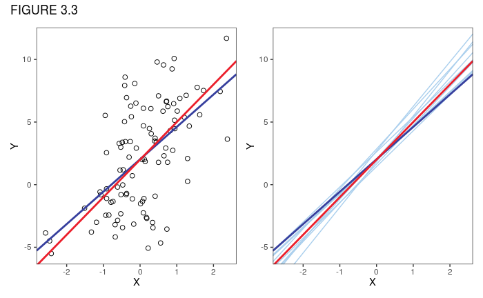

```r
colors_3.3 <- c("red" = "#EB1F2B",
             "darkblue" = "#37409E",
             "lightblue" = "#AACFED")

n <- 100
x1 <- rnorm(100, sd = 1)
y1 <- 2 + 3*x1 + rnorm(100, sd = 3)
coefs1 <- lsfit(x1, y1)$coef

p1 <- data.frame(x = x1, y = y1) %>%
  ggplot(aes(x, y)) +
  geom_point(size = 2, shape = 21) +
  geom_abline(intercept = coefs1[1], slope = coefs1[2],
              color = colors_3.3["darkblue"],
              size = 1) +
  geom_abline(intercept = 2, slope = 3,
              color = colors_3.3["red"],
              size = 1) +
  labs(x = "X", y = "Y") +
  lims(x = c(min(x1), max(x1)), y = c(min(y1), max(y1))) +
  theme(panel.grid = element_blank())

# Generate 10 different least squares lines on random data sets:
coefs <- matrix(0, ncol = 2, nrow = 10)
for(i in 1:10) {
  x <- rnorm(100, sd = 1)
  y <- 2 + 3*x + rnorm(100, sd = 3)
  lsfit_coefs <- lsfit(x, y)$coef
  coefs[i, 1] <- lsfit_coefs[1]
  coefs[i, 2] <- lsfit_coefs[2]
}

p2 <- data.frame(x = x1, y = y1) %>%
  ggplot() +
  geom_abline(data = data.frame(coefs),
              aes(intercept = X1, slope = X2),
              color = colors_3.3["lightblue"]) +
  geom_abline(intercept = coefs1[1], slope = coefs1[2],
              color = colors_3.3["darkblue"],
              size = 1) +
  geom_abline(intercept = 2, slope = 3,
              color = colors_3.3["red"],
              size = 1) +
  labs(x = "X", y = "Y") +
  lims(x = c(min(x1), max(x1)), y = c(min(y1), max(y1))) +
  theme(panel.grid = element_blank())

p1 + p2 +plot_annotation(title = "FIGURE 3.3")
```

### Table 3.1

```r
get_regression_coefs(mod, 4)
```

```
            Estimate Std. Error t value Pr(>|t|)
(Intercept)   7.0326     0.4578 15.3603        0
TV            0.0475     0.0027 17.6676        0
```

Manually calculate the 95% CI (matches text, page 67):

```r
mod_summary <- summary(mod)
coefs <- mod_summary$coefficients
alpha <- 0.05
df <- nrow(Ad) - 2
t <- qt(1 - alpha/2, df)
str_interp("The ${100*(1 - alpha)}% CI for the intercept is [${round(coefs[1, 1] - t*coefs[1, 2], 3)}, ${round(coefs[1, 1] + t*coefs[1, 2], 3)}]")
```

```
[1] "The 95% CI for the intercept is [6.13, 7.935]"
```

```r
str_interp("The ${100*(1 - alpha)}% CI for the slope is [${round(coefs[2, 1] - t*coefs[2, 2], 3)}, ${round(coefs[2, 1] + t*coefs[2, 2], 3)}]")
```

```
[1] "The 95% CI for the slope is [0.042, 0.053]"
```

Test $H_0: \beta_1 = 0$:

```r
t <- (coefs[2, 1])/coefs[2, 2] # matches the result in summary(mod) above
2 * (1 - pt(abs(t), df)) # p-value
```

```
[1] 0
```

### Table 3.2

View summary of the linear model which includes the data from Table 3.2:

```r
mod %>% summary()
```

```
Call:
lm(formula = sales ~ TV, data = Ad)

Residuals:
    Min      1Q  Median      3Q     Max
-8.3860 -1.9545 -0.1913  2.0671  7.2124

Coefficients:
            Estimate Std. Error t value Pr(>|t|)
(Intercept) 7.032594   0.457843   15.36   <2e-16 ***
TV          0.047537   0.002691   17.67   <2e-16 ***
---
Signif. codes:  0 ‘***’ 0.001 ‘**’ 0.01 ‘*’ 0.05 ‘.’ 0.1 ‘ ’ 1

Residual standard error: 3.259 on 198 degrees of freedom
Multiple R-squared:  0.6119,    Adjusted R-squared:  0.6099
F-statistic: 312.1 on 1 and 198 DF,  p-value: < 2.2e-16
```

Calculate RSE using (3.15):

```r
n <- nrow(Ad)
sqrt((1/(n - 2))*sum(mod$residuals^2))
```

```
[1] 3.258656
```

Calculate R Squared using (3.17):

```r
y.bar <- mean(Ad$sales)
TSS <- sum((Ad$sales - y.bar)^2)
RSS <- sum(mod$residuals^2)
R_sq <- (TSS - RSS)/TSS
R_sq
```

```
[1] 0.6118751
```

## 3.2 Multiple Linear Regression

### TABLE 3.3

```r
get_regression_coefs(lm(sales ~ radio, data = Ad), 3)
```

```
            Estimate Std. Error t value Pr(>|t|)
(Intercept)    9.312      0.563  16.542        0
radio          0.202      0.020   9.921        0
```

```r
get_regression_coefs(lm(sales ~ newspaper, data = Ad), 3)
```

```
            Estimate Std. Error t value Pr(>|t|)
(Intercept)   12.351      0.621  19.876    0.000
newspaper      0.055      0.017   3.300    0.001
```

### TABLE 3.4

```r
get_regression_coefs(lm(sales ~ ., data = Ad), 3)
```

```
            Estimate Std. Error t value Pr(>|t|)
(Intercept)    2.939      0.312   9.422     0.00
TV             0.046      0.001  32.809     0.00
radio          0.189      0.009  21.893     0.00
newspaper     -0.001      0.006  -0.177     0.86
```

### TABLE 3.5

```r
cor(Ad) %>% round(4)
```

```
              TV  radio newspaper  sales
TV        1.0000 0.0548    0.0566 0.7822
radio     0.0548 1.0000    0.3541 0.5762
newspaper 0.0566 0.3541    1.0000 0.2283
sales     0.7822 0.5762    0.2283 1.0000
```

### TABLE 3.6

```r
mod_summary_2 <- summary(lm(sales ~ ., data = Ad))
mod_summary_2
```

```
Call:
lm(formula = sales ~ ., data = Ad)

Residuals:
    Min      1Q  Median      3Q     Max
-8.8277 -0.8908  0.2418  1.1893  2.8292

Coefficients:
             Estimate Std. Error t value Pr(>|t|)
(Intercept)  2.938889   0.311908   9.422   <2e-16 ***
TV           0.045765   0.001395  32.809   <2e-16 ***
radio        0.188530   0.008611  21.893   <2e-16 ***
newspaper   -0.001037   0.005871  -0.177     0.86
---
Signif. codes:  0 ‘***’ 0.001 ‘**’ 0.01 ‘*’ 0.05 ‘.’ 0.1 ‘ ’ 1

Residual standard error: 1.686 on 196 degrees of freedom
Multiple R-squared:  0.8972,    Adjusted R-squared:  0.8956
F-statistic: 570.3 on 3 and 196 DF,  p-value: < 2.2e-16
```

Calculate p-value for the F-statistic:

```r
2 * (1 - pf(mod_summary_2$fstatistic[1], df1 = mod_summary_2$fstatistic[2], df2 = mod_summary_2$fstatistic[3]))
```

```
value
    0
```

Calculate Multiple R-squared:

```r
cor(Ad$sales, lm(sales ~ ., data = Ad)$fitted.value)^2
```

```
[1] 0.8972106
```

Calculating the confidence and prediction intervals on page 82:

```r
mod_3 <- lm(sales ~ TV + radio, data = Ad)
predict(mod_3, newdata = data.frame(TV = 100, radio = 20), interval = "confidence") * 1000
```

```
       fit      lwr      upr
1 11256.47 10985.25 11527.68
```

```r
predict(mod_3, newdata = data.frame(TV = 100, radio = 20), interval = "pred") * 1000
```

```
       fit      lwr      upr
1 11256.47 7929.616 14583.32
```

## 3.3 Other Considerations in the Regression Model

View `Credit` data:

```r
Credit
```

| ID | Income | Limit | Rating | Cards | Age | Education | Gender | Student | Married | Ethnicity | Balance |
| --- | --- | --- | --- | --- | --- | --- | --- | --- | --- | --- | --- |
| 1 | 14.891 | 3606 | 283 | 2 | 34 | 11 | Male | No | Yes | Caucasian | 333 |
| 2 | 106.025 | 6645 | 483 | 3 | 82 | 15 | Female | Yes | Yes | Asian | 903 |
| 3 | 104.593 | 7075 | 514 | 4 | 71 | 11 | Male | No | No | Asian | 580 |
| 4 | 148.924 | 9504 | 681 | 3 | 36 | 11 | Female | No | No | Asian | 964 |
| 5 | 55.882 | 4897 | 357 | 2 | 68 | 16 | Male | No | Yes | Caucasian | 331 |
| 6 | 80.180 | 8047 | 569 | 4 | 77 | 10 | Male | No | No | Caucasian | 1151 |
| 7 | 20.996 | 3388 | 259 | 2 | 37 | 12 | Female | No | No | African American | 203 |
| 8 | 71.408 | 7114 | 512 | 2 | 87 | 9 | Male | No | No | Asian | 872 |
| 9 | 15.125 | 3300 | 266 | 5 | 66 | 13 | Female | No | No | Caucasian | 279 |
| 10 | 71.061 | 6819 | 491 | 3 | 41 | 19 | Female | Yes | Yes | African American | 1350 |

[output cut: 390 more lines]

### FIGURE 3.6

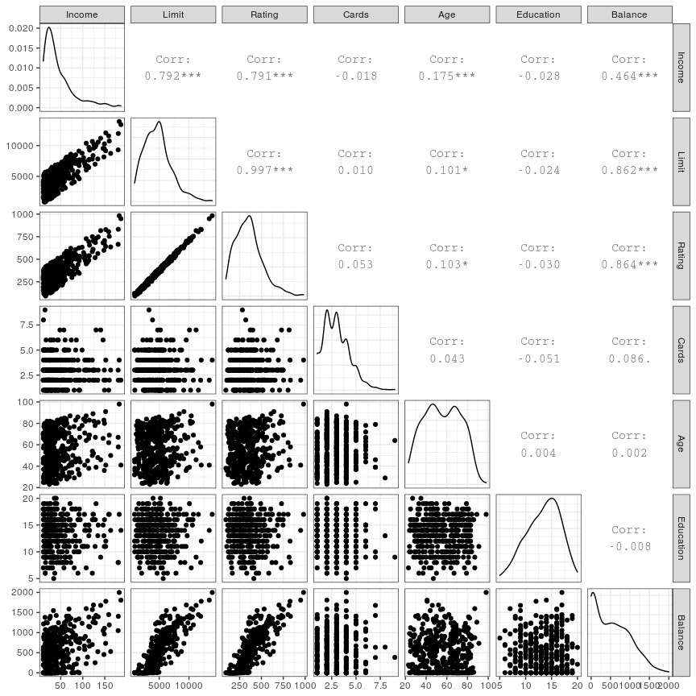

```r
is_numeric_cols <- Credit %>%
  mutate(ID = factor(ID)) %>%
  map_lgl(is.numeric)

GGally::ggpairs(Credit[ , is_numeric_cols], progress = F)
```

### TABLE 3.7

```r
get_regression_coefs(lm(Balance ~ Gender, data = Credit), 2)
```

```
             Estimate Std. Error t value Pr(>|t|)
(Intercept)    509.80      33.13   15.39     0.00
GenderFemale    19.73      46.05    0.43     0.67
```

### TABLE 3.8

```r
get_regression_coefs(lm(Balance ~ Ethnicity, data = Credit), 2)
```

```
                   Estimate Std. Error t value Pr(>|t|)
(Intercept)          531.00      46.32   11.46     0.00
EthnicityAsian       -18.69      65.02   -0.29     0.77
EthnicityCaucasian   -12.50      56.68   -0.22     0.83
```

Full model summary (for Table 3.8):

```r
lm(Balance ~ Ethnicity, data = Credit) %>%
  summary()
```

```
Call:
lm(formula = Balance ~ Ethnicity, data = Credit)

Residuals:
    Min      1Q  Median      3Q     Max
-531.00 -457.08  -63.25  339.25 1480.50

Coefficients:
                   Estimate Std. Error t value Pr(>|t|)
(Intercept)          531.00      46.32  11.464   <2e-16 ***
EthnicityAsian       -18.69      65.02  -0.287    0.774
EthnicityCaucasian   -12.50      56.68  -0.221    0.826
---
Signif. codes:  0 ‘***’ 0.001 ‘**’ 0.01 ‘*’ 0.05 ‘.’ 0.1 ‘ ’ 1

Residual standard error: 460.9 on 397 degrees of freedom
Multiple R-squared:  0.0002188, Adjusted R-squared:  -0.004818
F-statistic: 0.04344 on 2 and 397 DF,  p-value: 0.9575
```

### TABLE 3.9

```r
get_regression_coefs(lm(sales ~ TV * radio, data = Ad), 4)
```

```
            Estimate Std. Error t value Pr(>|t|)
(Intercept)   6.7502     0.2479 27.2328   0.0000
TV            0.0191     0.0015 12.6990   0.0000
radio         0.0289     0.0089  3.2408   0.0014
TV:radio      0.0011     0.0001 20.7266   0.0000
```

### FIGURE 3.7

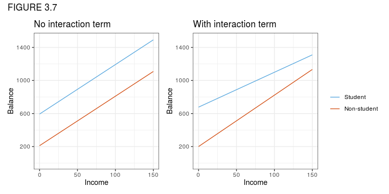

```r
lm1 <- lm(Balance ~ Income + Student, data = Credit)
lm2 <- lm(Balance ~ Income*Student, data = Credit)

grid <- expand_grid(Income = 0:150, Student = c("No", "Yes"))
grid$pred1 <- predict(lm1, newdata = grid)
grid$pred2 <- predict(lm2, newdata = grid)

colors <- c("#5DAADF", "#D45319") # blue, brown
p1 <- ggplot(grid) +
  geom_line(aes(Income, pred1, color = Student)) +
  labs(x = "Income", y = "Balance", color = NULL,
       title = "No interaction term") +
  scale_y_continuous(breaks = seq(200, 1400, 400), limits = c(0, 1500)) +
  scale_color_manual(breaks = c("Yes", "No"), labels = c("Student", "Non-student"), values = colors)

p2 <- ggplot(grid) +
  geom_line(aes(Income, pred2, color = Student)) +
  labs(x = "Income", y = "Balance", color = NULL,
       title = "With interaction term") +
  scale_y_continuous(breaks = seq(200, 1400, 400), limits = c(0, 1500)) +
  scale_color_manual(breaks = c("Yes", "No"), labels = c("Student", "Non-student"), values = colors)

p1 + p2 + plot_annotation("FIGURE 3.7") + plot_layout(guides = "collect")
```

### FIGURE 3.8

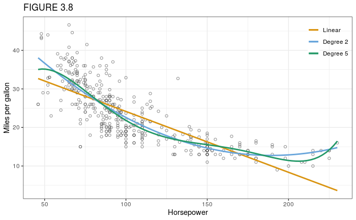

```r
colors <- c("#D99411", "#68A5DB", "#249968") # orange, blue, green
ggplot(Auto, aes(horsepower, mpg)) +
  geom_point(color = "grey30", shape = 1, alpha = 0.7) +
  geom_smooth(aes(color = "Linear"), method = "lm", formula = y ~ x, se = F) +
  geom_smooth(aes(color = "Degree 2"), method = "lm", formula = y ~ poly(x, 2), se = F) +
  geom_smooth(aes(color = "Degree 5"), method = "lm", formula = y ~ poly(x, 5), se = F) +
  labs(x = "Horsepower", y = "Miles per gallon", color = NULL,
       title = "FIGURE 3.8") +
  scale_color_manual(breaks = c("Linear", "Degree 2", "Degree 5"), values = colors) +
  theme(legend.position = c(1, 1),
        legend.justification = c(1, 1),
        legend.background = element_blank())
```

### TABLE 3.10

```r
get_regression_coefs(lm(mpg ~ poly(horsepower, 2, raw = TRUE), data = Auto), rounding = 4)
```

```
                                 Estimate Std. Error  t value Pr(>|t|)
(Intercept)                       56.9001     1.8004  31.6037        0
poly(horsepower, 2, raw = TRUE)1  -0.4662     0.0311 -14.9782        0
poly(horsepower, 2, raw = TRUE)2   0.0012     0.0001  10.0801        0
```

## TODO create FIGURE 3.9

### FIGURE 3.14

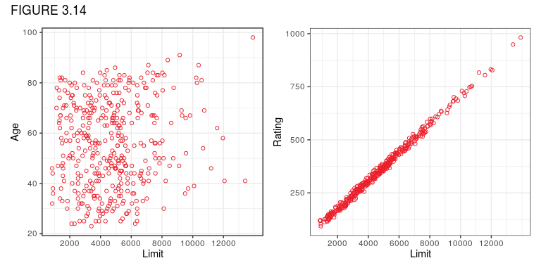

```r
p1 <- ggplot(Credit) +
  geom_point(aes(Limit, Age), color = "#EB1F2B", shape = 1) + # red
  scale_x_continuous(breaks = seq(2e3, 12e3, 2e3))

p2 <- ggplot(Credit) +
  geom_point(aes(Limit, Rating), color = "#EB1F2B", shape = 1) + # red
  scale_x_continuous(breaks = seq(2e3, 12e3, 2e3))

p1 + p2 + plot_annotation(title = "FIGURE 3.14")
```

### TABLE 3.11

```r
get_regression_coefs(lm(Balance ~ Age + Limit, data = Credit), 3)
```

```
            Estimate Std. Error t value Pr(>|t|)
(Intercept) -173.411     43.828  -3.957    0.000
Age           -2.291      0.672  -3.407    0.001
Limit          0.173      0.005  34.496    0.000
```

```r
get_regression_coefs(lm(Balance ~ Rating + Limit, data = Credit), 3)
```

```
            Estimate Std. Error t value Pr(>|t|)
(Intercept) -377.537     45.254  -8.343    0.000
Rating         2.202      0.952   2.312    0.021
Limit          0.025      0.064   0.384    0.701
```

Calculate VIF values (match text, pg 102):

```r
Credit_subset <- Credit %>%
  select(age = Age,
         rating = Rating,
         limit = Limit)
R_sq1 <- lm(age ~ ., data = Credit_subset) %>% summary() %>% .$r.squared
R_sq2 <- lm(rating ~ ., data = Credit_subset) %>% summary() %>% .$r.squared
R_sq3 <- lm(limit ~ ., data = Credit_subset) %>% summary() %>% .$r.squared

1/(1 - R_sq1)
```

```
[1] 1.011385
```

```r
1/(1 - R_sq2)
```

```
[1] 160.6683
```

```r
1/(1 - R_sq3)
```

```
[1] 160.5929
```

[^1]: James G, Witten D, Hastie T, Tibshirani R (2013). *An Introduction to Statistical Learning: with Applications in R*. Springer, 1st edition.